# Project 1

Quinn Muzzio

12/15/2022

### Loading and Preprocessing the data (and also providing a summary just so I know it works).

```r
DATA=read.csv("C:\\Users\\quinn\\OneDrive\\Documents\\Reproducible Research 1\\repdata_data_activity\\activity.csv")
#Summary of the Data so I can double check my anwsers.
summary(DATA)
```

```
##      steps            date              interval
##  Min.   :  0.00   Length:17568       Min.   :   0.0
##  1st Qu.:  0.00   Class :character   1st Qu.: 588.8
##  Median :  0.00   Mode  :character   Median :1177.5
##  Mean   : 37.38                      Mean   :1177.5
##  3rd Qu.: 12.00                      3rd Qu.:1766.2
##  Max.   :806.00                      Max.   :2355.0
##  NA's   :2304
```

```r
#Change Dates to Dates
DATA$date <- as.Date(DATA$date, format = "%Y-%m-%d")
```

# What is mean total number of steps taken per day?

## For this part of the assignment, you can ignore the missing values in the dataset.

### Calculate the total number of steps taken per day

### If you do not understand the difference between a histogram and a barplot, research the difference between them. Make a histogram of the total number of steps taken each day

### Calculate and report the mean and median of the total number of steps taken per day

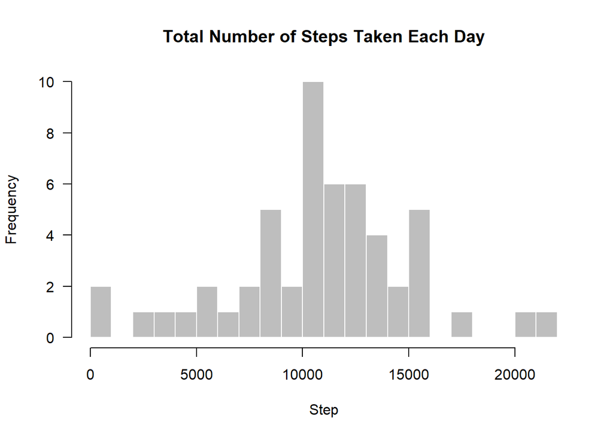

```r
#Total number of steps per day
TotalSteps = aggregate(steps ~ date, data = DATA, sum, na.rm = TRUE)

#Histogram of number of steps per day
hist(TotalSteps$steps, breaks = 20,
      main = "Total Number of Steps Taken Each Day",
      col = "grey", border = "white", xlab = "Step", axes = FALSE)
      axis(1)
      axis(2, las = 1)
```

```r
#Mean of steps per day
mean(TotalSteps$steps, na.rm = TRUE)
```

```
## [1] 10766.19
```

```r
#Median of steps per day
median(TotalSteps$steps, na.rm = TRUE)
```

```
## [1] 10765
```

Note: na.rm = TRUE excludes missing values.

# What is the average daily activity pattern?

### Make a time series plot (i.e. type = “l”) of the 5-minute interval (x-axis) and the average number of steps taken, averaged across all days (y-axis)

### Which 5-minute interval, on average across all the days in the dataset, contains the maximum number of steps?

```r
#First Create Average Number of steps taken.
AverageSteps = aggregate(steps ~ interval, data = DATA, mean, na.rm = TRUE)

#Creating the time plot
#Note: It is type L, not type 1. Took me way to long to figure that one out. ( l 1 l )
plot(AverageSteps$interval, AverageSteps$steps, type='l' ,
      main = "Time Series: Average Number of Steps Taken", axes = FALSE,
      xlab = "5-minute interval", ylab = "Average number of steps"           )
      axis(1)
      axis(2, las = 1)

#Then find interval
DATA$interval[ which.max( AverageSteps$steps ) ]
```

```
## [1] 835
```

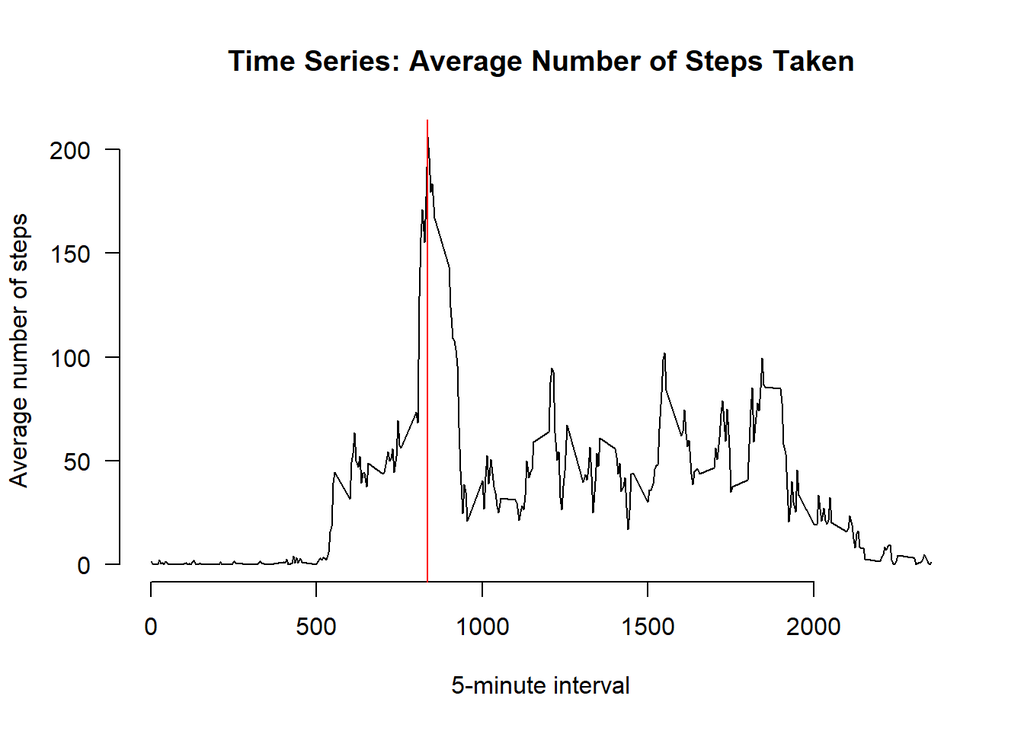

```r
#Checking my work
abline( v=DATA$interval[ which.max( AverageSteps$steps ) ], col="red")
```